# IA más allá del prompt

RAG, automatización y memoria

2026-01-11

# Enlaces

- segana@fen.uchile.cl
- https://segana.netlify.app
- https://www.linkedin.com/in/sebastian-egana-santibanez/
- https://github.com/sebaegana

# ¿Por qué ir más allá?

Cuando ya debemos pasar de la interacción un poco más simple e intentar estabilizar lo que obtenemos desde los LLM’s.

# Mensaje central

- Para que los LLM generen valor real en organizaciones, debemos estabilizar sus salidas mediante contexto controlado, flujos reproducibles y persistencia de conocimiento.

## El problema: la inestabilidad de los LLM

Los LLM’s son probabilísticos, no deterministas.

El mismo prompt → resultados distintos

Sensibles a:

- Orden del texto
- Contexto previo
- Temperatura
- Estado de la conversación

¿Que implica esto?

- Buen desempeño en demos
- ❌ Frágiles en producción
- ❌ Difíciles de auditar
- ❌ Resultados no reproducibles

## ¿Por qué el prompt no escala?

**Aquí ocurre el quiebre conceptual**

El prompt:

- Vive en la cabeza del usuario
- No es versionable
- No es auditable
- No es reproducible

📌 **Analogía potente**

> Usar solo prompts es como entrenar un modelo “de memoria” cada vez.

## Objetivo real: estabilizar la salida del modelo

**Cambio de foco**

No buscamos:

- “respuestas creativas”

Buscamos:

- consistencia
- trazabilidad
- control
- alineamiento con negocio

📌 **Introduce el concepto**

> LLM como componente, no como oráculo

## Primer pilar: RAG (Retrieval-Augmented Generation)

**Qué problema resuelve**

- Alucinaciones
- Conocimiento obsoleto
- Dependencia del prompt

**Qué hace RAG**

Separa:

- conocimiento (documentos)
- razonamiento (modelo)

**El modelo no inventa, recupera**

📌 **Frase clave**

> RAG transforma un LLM genérico en un sistema experto contextual.

## En detalle

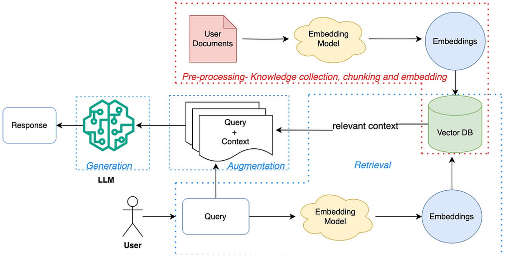

Recuperada en: https://mindfulmatrix.substack.com/p/build-a-simple-llm-application-with?utm_source=chatgpt.com

## Segundo pilar: Automatización (orquestación)

Problema:

- Uso manual
- Resultados no repetibles
- Dependencia humana

Automatizar implica

- Flujos definidos
- Entradas controladas
- Salidas esperadas
- Evaluación automática

## 💻 Ejemplo de un flujo

[figure not shown]

Ejemplo generado dentro del curso

## 🤯 ¿Dónde entra el LLM?

**System Instructions**

Role: You are a highly intelligent and accurate sentiment analyzer.

Task: Analyze the sentiment of the provided text and categorize it into one of the following classes:

- Positive
- Neutral
- Negative

**Output Rules**

- Output only JSON
- Follow the provided formatting instructions strictly
- Do not include any additional text outside the JSON

**Output Format Constraint**

**JSON Schema Compliance**

- The output must conform exactly to a given JSON Schema instance.
- All required fields must be present.
- No extra fields are allowed.
- No trailing commas.

Schema:

```
{
  "$schema": "http://json-schema.org/draft-07/schema#",
  "type": "object",
  "properties": {
    "sentiment": {
      "type": "string",
      "enum": ["Positive", "Neutral", "Negative"]
    },
    "strength": {
      "type": "number",
      "minimum": 0,
      "maximum": 1,
      "description": "Strength score for sentiment in relation to the category"
    },
    "confidence": {
      "type": "number",
      "minimum": 0,
      "maximum": 1
    }
  },
  "required": ["sentiment", "strength", "confidence"],
  "additionalProperties": false
}
```

## 📌 **Frase clave:**

> Sin automatización, la IA es solo una herramienta; con automatización, es un sistema.

El paso posterior a esto es la construcción de agentes en donde el LLM opera como un orquestador de distintas herramnientas, que pueden ser tan simple como una calculadora o más compleja como otro LLM, entre otras.

## Tercer pilar: Memoria (estado y aprendizaje)

**Qué NO es memoria**

- Historial infinito del chat ❌

**Qué SÍ es memoria**

- Persistencia selectiva
- Estado del proceso
- Preferencias
- Decisiones pasadas

**Tipos**

- 🟢 Memoria de corto plazo (ventana de contexto): se mantiene dentro de la covnersación y está limitada por tokens
- 🔵 Memoria de largo plazo (vectores / DB): permite “recuerdar” en el largo plazo y habilita la posibilidad de personalizar al modificarla
- 🟠 Memoria operacional (estado del flujo): relacionada con agentes y orientada a determinar los pasos del proceso y el estado en el que se encuentra

## La integración: Prompt + RAG + Automatización + Memoria

Aquí está la tesis completa

Componente Rol Prompt Interfaz humana RAG Contexto confiable Automatización Repetibilidad Memoria Continuidad

**Mensaje central:**

> La estabilidad no viene del prompt, sino del sistema.

## Implicancias para organizaciones

🛬 **Aterrizaje ejecutivo**

Menos riesgo Menos alucinaciones Más confianza Escalabilidad real Auditoría y control

📌 **Cambio de mentalidad:**

> No implementar IA → diseñar sistemas con IA.

## Cierre

> El futuro de la IA no es escribir mejores prompts, es diseñar mejores sistemas.

# Referencias

Gandhi, S. (2024, April 7). Building LLM application using RAG: How to query your document using LLM. Mindful Matrix. Retrieved from https://mindfulmatrix.substack.com/p/build-a-simple-llm-application-with